# Jacob Tiede

## Adversarial Examples Generated with GANs

For this section of the project I will detail a new way of generating adversarial examples. This will involve a GAN structure to generate high quality images, but still minimize the odds of a pre trained neural net being correct in its classification. First let's detail the problem that we seek to solve:

## What are Adversarial Examples

One eccentricity about neural nets is the existence of so-called 'avisarial examples'. These are derived from examples which are classified as a given class $i$, with a high certainty in a pre trained neural net, but with a small perturbation that is usually imperceptible to humans makes the example classified to a different class $j$. We can define this in symbols: if our pre trained neural net is a function $\Phi$, and our original image is a tensor $x$ then we know that $\Phi(x) = c_i$ with a high probability ($c_i$ is the ith class that our neural net classifies to). This means that we would like to generate some noise tensor $r$ such that:

$$ \begin{align*} \Phi(x+r) &= c_j\\ s.t. j &\neq i \end{align*} $$

This is, at a high level, correct, but the devil is in the details. $r$ is an arbitrary tensor right now, so it could, in theory, adjust $x$ so greatly that the image becomes unrecognizable, or qualitatively a different image in general. This is counter productive to our goal since we would like the adversarial image $x+r$ to be as close to the original as possible, meaning we need some way to "reign in" our neural net. [1] offers one such way through its use of constraints on $r$. If we define a loss like this:

$$ min_r c||r||_2 $$

Where $c$ is some scalar, and $||r||_2$ is the L2 norm of $r$. Then we should, in theory, have a low magnitude r that results from the optimization that still makes $\Phi$ misclassify the image (of course there is also a term that penalizes $r$ if it doesn't make $\Phi$ misclassify $x$). This was one of the intriguing properties of neural nets detailed in [1], that you contrive an $r$ that is so small that humans cannot see the difference, but $\Phi$ still makes a mistake. The upshot is that we are able to generate adversarial examples for a given neural net which look almost the same as the original image.

Another highlight in this research field is the viability of so called one-pixel attacks [2]. This is adversarial noise that is generated with another constraint: that the noise itself cannot adjust more than one pixel. This works by using a genetic algorithm which I implemented in my seventh biweekly report. This shows that not only is it possible to generate a noise vector that will change a neural net's classification, but this vector can also be quite sparse.

## Problems with Previous Approaches

The main problem that I see with previous ideas is that each adversarial example must be rigorously trained and optimized. Each adversarial example requires its own optimization process, which seems as if it might be cumbersome. In an attempt to mitigate this problem I would like to propose a new algorithm for finding adversarial examples: a GAN. Let's start by talking about the general structure:

## General Structure of a GAN for Adversarial Example Generation

We will create a GAN that can generate the noise vector $r$ based on conditional information ($x$). In general we want two things with this model: for $x+r$ to be convincingly a member of the data (and still convincingly a member of whatever class it was originally), and for $x+r$ to make a pretrained model misclassify this image.

In general this will work as follows: $x$ is input to the generator $G$ -> $G$ outputs a tensor of a same shape as $x$ (this is $r$) -> $r$ is penalized based on its size and density (meaning $r$ should be sparse as in [2]) -> $x+r$ is input into a discriminator to ensure that it is still convincingly a member of the data -> $x+r$ is input into a model and $G$ is penalized if it does not fool the original data. Each of these will involve a loss which I will detail to below, but for now here is a general picture of what I will implement:

[figure not shown]

Let's start by talking about the structure of each of the neural nets in the picture: $G$, $D$, and $\Phi$

### The Structure of each Neural Net

Let's start by talking about $\Phi$ since it will be the network we are focused on fooling. This is a pre trained neural net that will be used for classification. We need our GAN to generate noise that, when added to the original image, will fool this network. In our implementation we will take advantage of transfer learning to get state of the art accuracy on MNIST (the data we will be using to fool the network). For this we will use pretrained ResNet-18 as the backbone which we will fine tune. I implemented this in my seventh biweekly report, and I found that it got 99% accuracy on a hold out set.

Now we can talk about $G$ which will just be a normal conditional generator (which takes conditional input as a tensor of shape (1, 28, 28) in the case of MNIST, and outputs an image of the same shape). This will follow the structure of the generator that we found in the first half of this project using a U-Net structure with an ASPP attention module (see the first half of this project for more information on this).

$D$ is simply the discriminator we will use in this set up. I've opted not to use a conditional discriminator despite the possibility of it more tightly regulating that the image generated still looks like the original class. This is because I believe that the penalization on the $r$ tensor generated by $G$ for large and dense inputs should be sufficient to stop the generator from completely changing the original image to something else. Now I would like to talk about the loss functions I will employ:

### The Losses

We've got four losses to talk about, two on $r$ and two on $x+r$, to start let's talk about the two losses on $r$.

#### The Size Loss

This is a loss on the absolute magnitude of $r$. We want $r$ to be as small in magnitude as we can get it, so we will introduce a loss much like that of [1]: $$ loss_{size} = ||r||_2 $$ By minimizing this we hope that the changes we do make will be minor, keeping the original content of the image intact.

#### Sparsity Loss

This loss is designed to make sure that the $r$ only adjusts a few values. We will take a page from TabNet's [3] book (which I reviewed in the second biweekly report) where we will have a penalty for dense masks. TabNet used this to try and force the network to make a sparse feature selection across its attentive masks, but we will use it to try and make $r$ sparse. In TabNet this was defined as:

$$ \lambda = \sum_{i=1}^{N_{steps}}\sum_{b=1}^B\sum_{j=1}^D-\frac{M_{b,j}[i]}{N_{steps}*B}*log(M_{b,j}[i]+\epsilon) $$

Where $M_{b,j}[i]$ was the $(b,j)$th element of the ith mask in TabNet, $N_{steps}$ was the number of masks, $B$ was the batch size, and $\epsilon$ was a term to make sure that the log was numerically stable. Let's consider why this was effective at encouraging sparse masks in TabNet so that we can use it in our project. We see that, since we have $M_{b,j}[i]$ as a term in the numerator of this expression (and since $\epsilon \neq 0$)), if $M_{b,j}[i]=0$ for all $b$, $j$, and $i$, then this sum will be zero. We can also note that if $M_{b,j}[i] > 0$ then $\lambda$ is negative for $M_{b,j}[i] + \epsilon > 1$ (so we will eventually use a tanh function to constrain our output), and positive for $M_{b,j}[i] + \epsilon < 1$. This means that this loss is actually pushing $M_{b,j}[i]$ to be less than $1-\epsilon$ in this case since the zero solution gives a loss of zero, and the more that $M_{b,j}[i] >0$ is pushed toward zero the smaller the loss will be. Now, $M_{b,j}[i]$ is assumed to be positive in the paper and less than one, which makes this loss an easy choice, but for our purposes $r$ needs to be negative for some values. To mitigate this we will need to make some changes to both make this valid for our purposes, and to make sure that it encourages gradient descent to make values zero in both directions. To do this I propose using two different functions: one for a positive value of $r$ (which we are treating as the mask $M[i]$)) and one for a negative value:

For positive values of $r$ ($r[i,j]$) we can apply the function:

$$ loss_{sparse}(r[i,j]) = -r[i,j]*log(r[i,j] + \epsilon), r[i,j] > 0 $$

And for negative values we can use the following slightly adjusted values:

$$ loss_{sparse}(r[i,j]) = r[i,j]*log(abs(r[i,j]) + \epsilon), r[i,j] < 0 $$

Then for all $i = 1...H$ and $j = 1...W$ we can define the complete sparse loss as:

$$ loss_{sparse} = \sum_{i=1}^H\sum_{j=1}^Wloss_{sparse}(r[i,j])/(H*W) $$

Note that the division by $H*W$ is just to take the mean of all of these losses. This should encourage sparse $r$ tensors in both directions (whether $r[i,j] > 0$ or $r[i,j] < 0$). Now we can talk about the discriminator loss and the adversarial loss:

#### Discriminator Loss

Per our observations at the start of this project we will not employ Wasserstein loss, and instead we will use the conventional cross entropy loss for the discriminator:

$$ loss_{fine}(D,G) = log(D(y_i)) + log(1-D(G(x_i,y_i))) $$

We won't use a patch discriminator since we are just trying to get a sense of whether the output image $x+r$ looks real or not (not necessarily whether all aspects of it are perfect).

#### Adversarial Loss

This loss will be a numerical gauge of whether or not $x+r$ will make $\Phi$ misclassify an example. For this loss we will seek to minimize the correct result (rather than maximize the classification of some other classes' probability output in $\Phi$, as some setups like that of [1] will incorporate). I will implement this simply as the negative of the normal cross entropy loss (which will make $G$ attempt to minimize the probability that $\Phi$ is correct, rather than maximize it as would be the usual method of training $\Phi$)

#### Putting All Of This Together

This will give a final loss that is the sum of all of the losses I just described. I will also add a scaling to each term to weigh the relative importance of each loss, though these will have to be found by hand since I don't think autoML is reasonable given my system resources.

## Implementation

I will implement this on the MNIST data set found here: https://www.kaggle.com/c/digit-recognizer/data?select=test.csv. To start I will quickly perform some EDA, but I have seen that the MNIST data is pretty well behaved for this problem set, so I doubt many changes will be required:

```python
import torch
import torch.nn as nn
import torch.nn.functional as F
import pandas as pd
import numpy as np
import time
import torchvision.models as models
from sklearn.metrics import accuracy_score
import matplotlib.pyplot as plt
from PIL import Image
import torchvision.transforms.functional as TF
import torchvision.transforms as transforms
import os
import matplotlib.pyplot as plt
import progressbar #If you're missing this library it is found here: https://pypi.org/project/progressbar2/
print("Is a GPU available? ")

#For reproducability
torch.backends.cudnn.deterministic = True
torch.manual_seed(0)
torch.cuda.manual_seed_all(0)
np.random.seed(0)
torch.cuda.is_available()
```

```
Is a GPU available?
```

```
True
```

```python
#To start we will load and format the training data in python:
import pandas as pd
trainData = pd.read_csv("./Data/MNIST_train.csv")
train_y = trainData['label'].to_numpy()
train_x = trainData.to_numpy()
#The first column is the label column so we will remove that
train_x = train_x[:,1:train_x.shape[1]]
#turn our data into torch tensors
train_y = torch.from_numpy(train_y)
train_x = torch.from_numpy(train_x)
print("The range of values for our data is: " + str(torch.min(train_x).item()) + " to " + str(torch.max(train_x).item()))
```

```
The range of values for our data is: 0 to 255
```

For our network to work we will need to rescale this to be in the range -1 to 1 (this is an idea I saw in my first biweekly report):

```python
#Rescale train_x so it is in [-1,1] for all values:
train_x = (train_x - 255/2)/(255/2)
```

```python
print("The range of values for our data is: " + str(torch.min(train_x).item()) + " to " + str(torch.max(train_x).item()))
```

```
The range of values for our data is: -1.0 to 1.0
```

Let's look at a histogram of average image values:

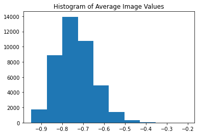

```python
avgs = torch.zeros(train_x.shape[0])
for i in range(train_x.shape[0]):
    avgs[i] = torch.mean(train_x[i,:])
plt.hist(avgs.numpy(), bins = 10)
plt.title("Histogram of Average Image Values")
plt.show()
```

This is skewed toward negative one, but this is due to the fact that the background is black (-1 in our scale). Lastly let's look at a histogram of the target vector:

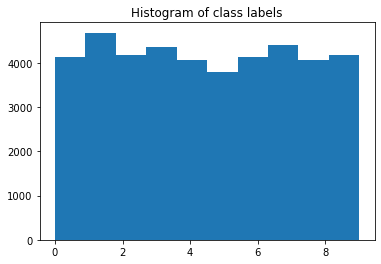

```python
plt.hist(train_y.numpy(), bins = 10)
plt.title("Histogram of class labels")
plt.show()
```

The classes look balanced, so no need to consider any rebalancing techniques. Now we can implement the neural network itself. First we will train the classification neural net that we would like to fool (using code from my seventh biweekly report). Note that I will start this section from scratch (reimporting things) since I will be rerunning this code as I experiment with how to set up the networks:

```python
import torch
import torch.nn as nn
import torch.nn.functional as F
import pandas as pd
import numpy as np
import time
import torchvision.models as models
from sklearn.metrics import accuracy_score
import matplotlib.pyplot as plt
from PIL import Image
import torchvision.transforms.functional as TF
import torchvision.transforms as transforms
import os
import matplotlib.pyplot as plt
import progressbar #If you're missing this library it is found here: https://pypi.org/project/progressbar2/
print("Is a GPU available? ")

#For reproducability
torch.backends.cudnn.deterministic = True
torch.manual_seed(0)
torch.cuda.manual_seed_all(0)
np.random.seed(0)
torch.cuda.is_available()
```

```
Is a GPU available?
```

```
True
```

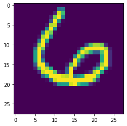

```python
#To start we will load and format the training data in python:
import pandas as pd
trainData = pd.read_csv("./Data/MNIST_train.csv")
train_y = trainData['label'].to_numpy()
train_x = trainData.to_numpy()
#The first column is the label column so we will remove that
train_x = train_x[:,1:train_x.shape[1]]
#turn our data into torch tensors
train_y = torch.from_numpy(train_y)
train_x = torch.from_numpy(train_x)
#We now need to reshape train_x so that it is in the correct format for the image classifier
train_x = train_x.view(train_x.shape[0], 1, int(np.sqrt(train_x.shape[1])), int(np.sqrt(train_x.shape[1])))

#Rescale train_x so it is in [-1,1] for all values:
train_x = (train_x - 255/2)/(255/2)

#Split into test and train datasets (since the MNIST_test.csv file is unlabeled)
from sklearn.model_selection import train_test_split
train_x, test_x, train_y, test_y = train_test_split(train_x, train_y, test_size=0.1, random_state=4)

#Now we'll look an image and write a function that will take a tensor and show the plot of the image
import matplotlib.pyplot as plt

def TImShow(image):
    image = image[0,:,:]
    plt.imshow(image.detach().numpy())
    plt.show()
TImShow(train_x[1,:,:,:])
```

```python
"""
Net -- defines a neural network that uses resnet18 as a pretrained backbone
"""
class Net(nn.Module):
    def __init__(self):
        super(Net, self).__init__()
        self.conv1 = nn.Conv2d(1,3,1)
        self.relu = nn.ReLU()
        self.convLayers = torch.nn.Sequential(*(list(models.resnet18(pretrained=True).children())[:-3]))
        self.global_avg = nn.AvgPool2d(2)
        self.fc1 = nn.Linear(256,50)
        self.fc2 = nn.Linear(50,50)
        self.fc3 = nn.Linear(50,10)
    def forward(self,x):
        x = self.relu(self.conv1(x))
        x = self.convLayers(x)
        x = self.global_avg(x)
        x = x.view(-1, 256)
        x = self.relu(self.fc1(x))
        x = self.relu(self.fc2(x))
        x = torch.softmax(self.fc3(x), dim = 1)
        return x

#train the net:
model = Net().cuda()

criterion = nn.CrossEntropyLoss()
learning_rate = 1e-4
optimizer = torch.optim.Adam(model.parameters(), lr=learning_rate)

batch_size = 64
steps = int(np.floor(train_x.shape[0]/batch_size))
epochs = 50
for epoch in range(epochs):
    running_loss = 0.0
    #shuffle the training data every epoch
    temp = torch.randperm(train_x.shape[0])
    train_x = train_x[temp, :, :, :]
    train_y = train_y[temp]
    for i in range(steps):
        optimizer.zero_grad()

        batch_x = train_x[batch_size*i:batch_size*(i+1),:,:,:].float().cuda()
        batch_y = train_y[batch_size*i:batch_size*(i+1)].cuda()

        out = model(batch_x)
        loss = criterion(out, batch_y.long())
        loss.backward()
        optimizer.step()
        running_loss+=loss.item()
        if i == steps-1 and epoch%10 == 9:
            print("The running loss for epoch " + str(epoch+1) + " was " + str(running_loss/steps))
```

```
The running loss for epoch 10 was 1.467207037998458
The running loss for epoch 20 was 1.4650644453905397
The running loss for epoch 30 was 1.4633158699940827
The running loss for epoch 40 was 1.4632875975915942
The running loss for epoch 50 was 1.4631428385184984
```

```python
model.eval()
acc = 0
running_loss = 0
for i in range(test_x.shape[0]):
    out = model(test_x[i,:,:,:].view(1,1,28,28).float().cuda())
    running_loss += criterion(out, test_y[i].view(1).cuda().long()).item()
    out = torch.argmax(out, dim = 1)

    if out == test_y[i]:
        acc+=1
print("The test accuracy was: " + str(acc/test_y.shape[0]))
print("The test loss was: " + str(running_loss/test_y.shape[0]))
```

```
The test accuracy was: 0.9914285714285714
The test loss was: 1.4693435919568651
```

Now we'll Implement the generator using some slight modifications to the earlier section of this project:

```python
"""
AttentiveFuse -- implements an attentive fuse operation as detailed by https://arxiv.org/pdf/1901.06322.pdf

@params - c_in: the number of input channels (it will output 1/2 this number, since that will keep the number of filters constant
                in the large network)
          c_out: The number of output channels in the convolutional layer
"""
class AttentiveFuse(nn.Module):
    def __init__(self, c_in, c_out):
        super(AttentiveFuse, self).__init__()
        self.c_in = c_in
        self.c_out = c_out
        #----------
        #The first convolutional layers:
        #----------
        self.convLayers1 = nn.Sequential(nn.Conv2d(self.c_in, self.c_out, 3, padding = 1),
                                        nn.ReLU(),
                                        nn.BatchNorm2d(self.c_out),
                                        nn.Conv2d(self.c_out, 2*self.c_out, 3, padding = 1),
                                        nn.ReLU(),
                                        nn.BatchNorm2d(2*self.c_out),
                                        nn.Conv2d(2*self.c_out, self.c_in, 3, padding = 1),
                                        nn.Sigmoid(),
                                        nn.BatchNorm2d(self.c_in))
        #----------
        #The second convolutional layers:
        #----------
        self.convLayers2 = nn.Sequential(nn.Conv2d(int(self.c_in/2), self.c_out, 3, padding = 1),
                                        nn.ReLU(),
                                        nn.BatchNorm2d(self.c_out),
                                        nn.Conv2d(self.c_out, int(self.c_in/2), 3, padding = 1),
                                        nn.ReLU(),
                                        nn.BatchNorm2d(int(self.c_in/2)))
    def forward(self, x, y):
        #----------
        #concatinate the two inputs
        #----------
        cat = torch.cat((x,y), dim = 1)

        #----------
        #apply the first convolutional layers
        #----------
        cat = self.convLayers1(cat)

        #----------
        #separate the attentive filters and multiply pointwise
        #----------
        x_att = cat[:,0:int(self.c_in/2),:,:]
        y_att = cat[:,int(self.c_in/2):cat.shape[1],:,:]

        x = x*x_att
        y = y*y_att

        #----------
        #add both of the inputs (scaled by attention) together
        #----------
        out = x+y

        #----------
        #Run out through the final convolutional layers
        #----------
        out = self.convLayers2(out)
        return out

"""
SpatialPooling -- Implements attentive spatial pooling as defined by https://arxiv.org/pdf/1901.06322.pdf

@params - c_in - input channels
          c_out - number of channels in the inbetween networks
          dilationRates - what dilation rates should we use in our convolutions for ASPP
"""
from torch.nn.parameter import Parameter
class SpatialPooling(nn.Module):
    def __init__(self, c_in, c_out = 32, dilationRates = [3,6,12,18]):
        super(SpatialPooling, self).__init__()
        #----------
        #Initialize parameters
        #----------
        self.dilationRates = dilationRates
        self.c_in = c_in
        self.c_out = c_out
        self.atrousConvs = nn.ModuleList([]) #Keeps track of the set of atrous convolutions
        self.fuses = nn.ModuleList([]) #Keeps track of the fusing modules

        #----------
        #Populate atrous Convs and fuses modules lists
        #We need 1 less fusion module than we have atrous convolution representation (so we have an if statement to take care of this)
        #Each atrous conv in this module will follow the form atrous conv -> relu -> batch normalization
        #----------
        for i in self.dilationRates:
            if i != self.dilationRates[0]:
                self.fuses.append(AttentiveFuse(self.c_out*2, 32))
            self.atrousConvs.append(nn.Sequential(nn.Conv2d(self.c_in, self.c_out, 3, padding = i, dilation = i),
                                             nn.ReLU(),
                                             nn.BatchNorm2d(self.c_out)))
        #----------
        #In order to apply the residual connection we will need to reduce the dimension of the output to have the same number of filters as
        #the input
        #----------
        self.convReduce = nn.Sequential(nn.Conv2d(self.c_out, self.c_in, 1),
                                        nn.ReLU(),
                                        nn.BatchNorm2d(self.c_in))

        #----------
        #Initialize the gamma in the residual scaling
        #----------
        self.gamma = Parameter(torch.zeros(1,1))
        self.gamma = nn.init.xavier_uniform_(self.gamma)
    def forward(self, x):
        #----------
        #Save the original x for the skip connection
        #----------
        x_mem = x.clone()

        #----------
        #Do the atrous convolutions, keeping track of each one in a list
        #----------
        savedConvs = []
        for i in range(len(self.atrousConvs)):
            savedConvs.append(self.atrousConvs[i](x))

        #----------
        #Fuse together all of the atrous convolutions
        #----------
        for i in range(len(self.fuses)):
            if i == 0:
                out = self.fuses[i](savedConvs[i], savedConvs[i+1])
            else:
                out = self.fuses[i](out, savedConvs[i+1])

        #----------
        #Reduce the number of filters in out so that it is the same as that of the input
        #----------
        out = self.convReduce(out)

        #----------
        #Create a residual connection with a learned scaling
        #----------
        out = out*self.gamma + (1-self.gamma)*x_mem
        return out
"""
encoderBlock - defines a single encoder block for the generator

@params: Cin - int, the number of input channels
         Cout - int, the number of output channels
         batchNorm - bool, tells us if we should use batch normalization for this layer or not
@methods: forward: defines the forward pass of the model
"""
class encoderBlock(nn.Module):
    def __init__(self, Cin, Cout, batchNorm = True):
        super(encoderBlock, self).__init__()
        self.conv = nn.Conv2d(Cin, Cout, 4, stride = 2, padding = 1) #reduces dim by 1/2
        self.BN = nn.BatchNorm2d(Cout)
        self.leReLU = nn.LeakyReLU(.2)
        self.batchNorm = batchNorm
    def forward(self, x):
        if self.batchNorm:
            x = self.leReLU(self.BN(self.conv(x)))
        else:
            x = self.leReLU(self.conv(x))
        return x

"""
decoderBlock - defines a decoder block for the generator

@params: Cin - int, the number of input channels
         Cout - int, the number of output channels
         useDrop - bool, whether or not to use a dropout layer
         batchNorm - bool, whether or not to use batch normalization
@methods: forward(self, x): defines the forward pass of the model
"""
class decoderBlock(nn.Module):
    def __init__(self, Cin, Cout, useDrop = True, batchNorm = True):
        super(decoderBlock, self).__init__()
        self.tConv = nn.ConvTranspose2d(Cin, Cout, 4, stride = 2, padding = 1) #upsamples by 2
        self.BN = nn.BatchNorm2d(Cout)
        self.drop = nn.Dropout(.5)
        self.useDrop = useDrop
        self.batchNorm = batchNorm
    def forward(self, x):
        if self.useDrop and self.batchNorm:
            x = self.drop(self.BN(self.tConv(x)))
        elif self.batchNorm:
            x = self.BN(self.tConv(x))
        else:
            x = self.tConv(x)
        return x

"""
Generator - defines a generator for our image translations task, expects images to be 512x512

@params - None
@methods: forward(self, x): Defines the forward pass of the model
"""
class Generator(nn.Module):
    def __init__(self):
        super(Generator, self).__init__()
        #-----------
        #U Net part
        #-----------
        #define our encoder blocks:
        #28x28
        self.enc1 = encoderBlock(1, 128, False)
        #14x14
        self.enc2 = encoderBlock(128, 128)
        #7x7
        #this is probably small enough to start adding decoder blocks (I was not able to make the full model due to RAM issues)
        self.dec1 = decoderBlock(128,128, False)
        #14x14
        self.dec2 = decoderBlock(128*2, 1, False, False)
        #28x28

        #-----------
        #ASPP Part
        #-----------
        self.ASPP = SpatialPooling(1)
        self.finalConv = nn.Sequential(nn.Conv2d(2,1,1),
                                       nn.BatchNorm2d(1))
        self.relu = nn.ReLU()
        self.tanh = nn.Tanh()
    def forward(self, x):
        x_mem = x.clone()
        #----------
        #ASPP on the input
        #----------
        xASPP = x.clone()
        xASPP = self.ASPP(xASPP)

        #list of the inputs to use in U-net
        temp = []

        #----------
        #contracting path
        #----------
        x = self.enc1(x)
        #append for use in U-net
        temp.append(x)
        x = self.enc2(x)

        #----------
        #dilating path
        #----------
        x = self.dec1(x)
        x = F.relu(torch.cat((x, temp[0]), dim = 1))

        #output
        x = self.relu(self.dec2(x))
        x = self.tanh(self.finalConv(torch.cat((x,xASPP), dim = 1)))
        x_mem = x+x_mem
        return x_mem, x
```

Now, Let's define a basic discriminator (using code adapted from my third biweekly report):

```python
"""
Discriminator - implement a discriminator. This uses the skeleton from my thrid biweekly report
"""
class Discriminator(nn.Module):
    #Note that exImg will contain and example image which we can get the dimension of NOTE: this should have dimension (1, 1, height, width)
    #batchSize will be the size of the batches
    def __init__(self):
        super(Discriminator, self).__init__()
        self.C64 = encoderBlock(1, 64, False)
        self.C128 = encoderBlock(64, 64)

        self.fc1 = nn.Linear(64*7*7, 1)
    def forward(self, x):
        x = self.C64(x)
        x = self.C128(x)
        x = x.view(-1,64*7*7)
        x = torch.sigmoid(self.fc1(x))
        return x
```

Now we can implement the sparsity loss (since this one will need to be a custom function):

```python
"""
NegativeSLoss -- Calculates the sparsity loss for a tensor of negative values

@params: - x, a tensor of only negative values
"""
def NegativeSLoss(x):
    eps = 10**-6
    loss = x*torch.log(torch.abs(x) + eps)
    return loss
"""
PostiveSLoss -- Calculates the sparsity loss for a tensor of positive values

@params: - x, a tensor of only positive values
"""
def PostiveSLoss(x):
    eps = 10**-6
    loss = -x*torch.log(x + eps)
    return loss

"""
SparseLoss -- Calculates the sparse loss for a tensor, returns a single value

@params: - x, a tensor of values that we would like the sparse loss of
"""
def SparseLoss(x):
    nLoss = NegativeSLoss(x*(x<0))
    pLoss = PostiveSLoss(x*(x>0))
    loss = torch.mean(nLoss+pLoss)
    return loss
```

Now we are ready to make the training loop since we will incorporate the rest of the losses within this loop:

```python
def getRealSamples(data, y, batch_size):
    temp = torch.randperm(batch_size)
    result = data[temp, :, :, :]
    result = result.float()
    y = y[temp].float()
    return result, y

criterion = nn.CrossEntropyLoss()
gen = Generator().cuda()
dis = Discriminator().cuda()
batch_size = 64
#define our two optimizers
learning_rate = 5e-5
#Use two separate RMSprop optimizers, one for the generator and one for the discriminator
gOptimizer = torch.optim.RMSprop(gen.parameters(), lr=learning_rate)
dOptimizer = torch.optim.RMSprop(dis.parameters(), lr=learning_rate)
#Now we will define the training loop:
epochs = 5
batchesPerEpoch = int(np.floor(train_x.shape[0]/batch_size))
with progressbar.ProgressBar(max_value=epochs*batchesPerEpoch) as bar:
    for epoch in range(epochs):
        running_gen_loss = 0
        for i in range(batchesPerEpoch):
            epsilon = 10**-6
            #get a minibatch of the real data
            batch_x, batch_y = getRealSamples(train_x, train_y, batch_size)
            batch_x = batch_x.cuda()
            batch_y = batch_y.cuda()
            #----------
            #Train discriminator on real data
            #----------
            dOptimizer.zero_grad()
            Dx = dis(batch_x)
            dxLoss = -1*torch.mean(torch.log(Dx+epsilon))
            #find the gradients for this step
            dxLoss.backward()

            #----------
            #Train discriminator on generated data
            #----------
            Gz, _ = gen(batch_x.float())
            DGz = dis(Gz)
            dgzLoss = 1*torch.mean(torch.log(1-DGz+epsilon))
            dgzLoss.backward()
            dOptimizer.step()


            #----------
            #Get the losses for the generator
            #----------
            gOptimizer.zero_grad()

            #----------
            #Get the mask, and generated image of the generator for this step
            #----------
            batch_x, batch_y = getRealSamples(train_x, train_y, batch_size)
            batch_x = batch_x.cuda()
            batch_y = batch_y.cuda()
            xr, r = gen(batch_x.float())

            #----------
            #Find the loss and grads for sparcity and size
            #----------
            loss_sparse = 1000*SparseLoss(r)
            loss_sparse.backward(retain_graph=True)
            loss_size = 10*torch.mean(torch.norm(r, dim = (2,3)))
            loss_size.backward(retain_graph=True)

            #----------
            #Find the loss against the discriminator
            #----------
            loss_dis = torch.mean(torch.log(dis(xr) + epsilon))
            loss_dis.backward(retain_graph=True)

            #----------
            #Find the classification loss
            #----------
            loss_adv = -10*criterion(model(xr), batch_y.long())
            loss_adv.backward()
            gOptimizer.step()
            bar.update(i+batchesPerEpoch*epoch)
print("Done traininig")
```

```
100% (2950 of 2950) |####################| Elapsed Time: 1:21:50 Time:  1:21:50
```

```
Done traininig
```

```
An example of a generated image:
```

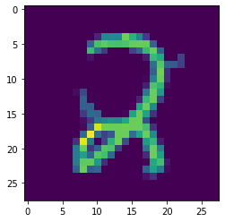

```python
print("An example of a generated image:")
TImShow(xr[0,:,:,:].cpu())
```

```
The image with no noise:
```

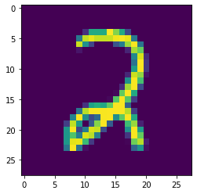

```python
print("The image with no noise:")
TImShow(batch_x[0,:,:,:].cpu())
```

Now let's look at our model's accuracy on the test images after we add generated noise:

```python
acc = 0
running_loss = 0
for i in range(test_x.shape[0]):
    with torch.no_grad():
        input, _ = gen(test_x[i,:,:,:].view(1,1,28,28).float().cuda())
        out = model(input)
    running_loss += criterion(out, test_y[i].view(1).cuda().long()).item()
    out = torch.argmax(out, dim = 1)

    if out == test_y[i]:
        acc+=1
print("The test accuracy after using the GAN was: " + str(acc/test_y.shape[0]))
print("The test loss after using the GAN was: " + str(running_loss/test_y.shape[0]))
```

```
The test accuracy after using the GAN was: 0.8890476190476191
The test loss after using the GAN was: 1.5722168125708897
```

I'm also curious to see if the training set was affected more than the test set:

```python
acc = 0
running_loss = 0
for i in range(train_x.shape[0]):
    with torch.no_grad():
        input, _ = gen(train_x[i,:,:,:].view(1,1,28,28).float().cuda())
        out = model(input)
    running_loss += criterion(out, train_y[i].view(1).cuda().long()).item()
    out = torch.argmax(out, dim = 1)

    if out == train_y[i]:
        acc+=1
print("The train accuracy after using the GAN was: " + str(acc/train_y.shape[0]))
print("The train loss after using the GAN was: " + str(running_loss/train_y.shape[0]))
```

```
The train accuracy after using the GAN was: 0.8958465608465609
The train loss after using the GAN was: 1.5657355744214285
```

It's also worth it to see the average $r$ tensor:

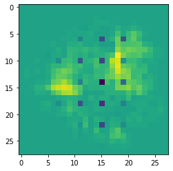

```python
TImShow(torch.mean(r.cpu(), dim = 0))
```

You can see that we have found certain groups of pixels that will sometimes fool $\Phi$. It is strange that there appears to be a group of evenly spaced pixels that are almost never chosen in the $r$ tensor, but this might just be one of the strange properties of neural nets (these pixels might just not be used for classification for whatever reason. You'll also note that we did use some pretty big scalings with the adversarial loss being multiplied by $10$, the size loss being multiplied by $10$, and the sparse loss being multiplied by $1000$. Now, it is worth noting that I scaled the sparse loss so much because in prior experiments I noticed that it was very easy for the model to converge to a very low loss for this, despite still having noise that was everywhere, so this large scaling was more to just make the loss on the same scale as the others. It is also worth saying that the loss scaling on the scale loss is important to make the images more close to the originals. I tried setting this to $1$, but it gives noise that substantially alters the original image, but it does also make $\Phi$ misclassify much more often. For instance we can rerun this training with only scaling the size loss by $1$:

```python
def getRealSamples(data, y, batch_size):
    temp = torch.randperm(batch_size)
    result = data[temp, :, :, :]
    result = result.float()
    y = y[temp].float()
    return result, y

criterion = nn.CrossEntropyLoss()
gen = Generator().cuda()
dis = Discriminator().cuda()
batch_size = 64
#define our two optimizers
learning_rate = 5e-5
#Use two separate RMSprop optimizers, one for the generator and one for the discriminator
gOptimizer = torch.optim.RMSprop(gen.parameters(), lr=learning_rate)
dOptimizer = torch.optim.RMSprop(dis.parameters(), lr=learning_rate)
#Now we will define the training loop:
epochs = 5
batchesPerEpoch = int(np.floor(train_x.shape[0]/batch_size))
with progressbar.ProgressBar(max_value=epochs*batchesPerEpoch) as bar:
    for epoch in range(epochs):
        running_gen_loss = 0
        for i in range(batchesPerEpoch):
            epsilon = 10**-6
            #get a minibatch of the real data
            batch_x, batch_y = getRealSamples(train_x, train_y, batch_size)
            batch_x = batch_x.cuda()
            batch_y = batch_y.cuda()
            #----------
            #Train discriminator on real data
            #----------
            dOptimizer.zero_grad()
            Dx = dis(batch_x)
            dxLoss = -1*torch.mean(torch.log(Dx+epsilon))
            #find the gradients for this step
            dxLoss.backward()

            #----------
            #Train discriminator on generated data
            #----------
            Gz, _ = gen(batch_x.float())
            DGz = dis(Gz)
            dgzLoss = 1*torch.mean(torch.log(1-DGz+epsilon))
            dgzLoss.backward()
            dOptimizer.step()


            #----------
            #Get the losses for the generator
            #----------
            gOptimizer.zero_grad()

            #----------
            #Get the mask, and generated image of the generator for this step
            #----------
            batch_x, batch_y = getRealSamples(train_x, train_y, batch_size)
            batch_x = batch_x.cuda()
            batch_y = batch_y.cuda()
            xr, r = gen(batch_x.float())

            #----------
            #Find the loss and grads for sparcity and size
            #----------
            loss_sparse = 1000*SparseLoss(r)
            loss_sparse.backward(retain_graph=True)
            loss_size = 1*torch.mean(torch.norm(r, dim = (2,3)))
            loss_size.backward(retain_graph=True)

            #----------
            #Find the loss against the discriminator
            #----------
            loss_dis = torch.mean(torch.log(dis(xr) + epsilon))
            loss_dis.backward(retain_graph=True)

            #----------
            #Find the classification loss
            #----------
            loss_adv = -10*criterion(model(xr), batch_y.long())
            loss_adv.backward()
            gOptimizer.step()
            bar.update(i+batchesPerEpoch*epoch)
print("Done traininig")
```

```
100% (2950 of 2950) |####################| Elapsed Time: 1:17:22 Time:  1:17:22
```

```
Done traininig
```

```
An example of a generated image:
```

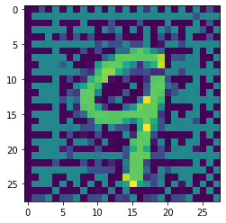

```python
print("An example of a generated image:")
TImShow(xr[0,:,:,:].cpu())
```

```
The image with no noise:
```

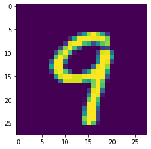

```python
print("The image with no noise:")
TImShow(batch_x[0,:,:,:].cpu())
```

```python
acc = 0
running_loss = 0
for i in range(test_x.shape[0]):
    with torch.no_grad():
        input, _ = gen(test_x[i,:,:,:].view(1,1,28,28).float().cuda())
        out = model(input)
    running_loss += criterion(out, test_y[i].view(1).cuda().long()).item()
    out = torch.argmax(out, dim = 1)

    if out == test_y[i]:
        acc+=1
print("The test accuracy after using the GAN was: " + str(acc/test_y.shape[0]))
print("The test loss after using the GAN was: " + str(running_loss/test_y.shape[0]))
```

```
The test accuracy after using the GAN was: 0.6816666666666666
The test loss after using the GAN was: 1.7776107588836125
```

```
Mean r
```

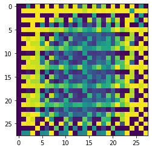

```python
print("Mean r")
TImShow(torch.mean(r.cpu(), dim = 0))
```

We can see that there is a greater degree of noise with the eased penalty of the size loss. We also see that these generated images fool $\Phi$ far more than the my last attempt of assigning weights to each loss. This tells me that there is probably some optimal scaling for the size loss that I have been unable to find as of yet. One question that I still have though is how consistent is this noise. Like is there a sort of standard noise that the generator applies to every picture (with small improvement depending on the image itself)? To assess this I would like to draw a heat map of values that remain the same with the right $r$ tensor in this most recent minibatch:

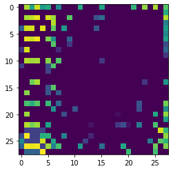

```python
sameR = torch.zeros(r.shape)
for i in range(r.shape[0]-1):
    sameR[i,:,:,:] = r[0,:,:,:] == r[i+1,:,:,:]
TImShow(torch.mean(sameR, dim = 0))
```

We can see that some of the pixels appear to be adjusted in the same way across all of the images (or most of them), so I do wonder what would happend if we just applied this common noise to all of the images and ran it back through $\Phi$:

```python
meanR = torch.mean(sameR, dim = 0)
commonNoise = r[0,:,:,:].cpu()*(meanR>.9)
acc = 0
running_loss = 0
for i in range(test_x.shape[0]):
    with torch.no_grad():
        input = test_x[i,:,:,:] + commonNoise
        input = input.cuda().view(1,1,28,28)
        out = model(input)
    running_loss += criterion(out, test_y[i].view(1).cuda().long()).item()
    out = torch.argmax(out, dim = 1)

    if out == test_y[i]:
        acc+=1
print("The test accuracy after adding common noise was: " + str(acc/test_y.shape[0]))
print("The test loss after adding common noise was: " + str(running_loss/test_y.shape[0]))
```

```
The test accuracy after adding common noise was: 0.9909523809523809
The test loss after adding common noise was: 1.469925180276235
```

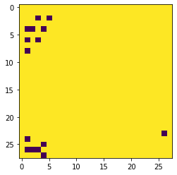

```python
TImShow(commonNoise)
```

Note that all of the yellow are zeros in this image. While there is noise that is common across many different images, this noise does not seem to be sufficient to cause misclassifications in $\Phi$, so the generator is required to understand what the image is and how to adjust it to make $\Phi$ make a mistake.

## More Ablation Studies

We will now conduct some more ablation studies where we see what happens if other potions of the loss are removed. First, I'd like to observe what would happen if we remove the size loss:

```python
def getRealSamples(data, y, batch_size):
    temp = torch.randperm(batch_size)
    result = data[temp, :, :, :]
    result = result.float()
    y = y[temp].float()
    return result, y

criterion = nn.CrossEntropyLoss()
gen = Generator().cuda()
dis = Discriminator().cuda()
batch_size = 64
#define our two optimizers
learning_rate = 5e-5
#Use two separate RMSprop optimizers, one for the generator and one for the discriminator
gOptimizer = torch.optim.RMSprop(gen.parameters(), lr=learning_rate)
dOptimizer = torch.optim.RMSprop(dis.parameters(), lr=learning_rate)
#Now we will define the training loop:
epochs = 5
batchesPerEpoch = int(np.floor(train_x.shape[0]/batch_size))
with progressbar.ProgressBar(max_value=epochs*batchesPerEpoch) as bar:
    for epoch in range(epochs):
        running_gen_loss = 0
        for i in range(batchesPerEpoch):
            epsilon = 10**-6
            #get a minibatch of the real data
            batch_x, batch_y = getRealSamples(train_x, train_y, batch_size)
            batch_x = batch_x.cuda()
            batch_y = batch_y.cuda()
            #----------
            #Train discriminator on real data
            #----------
            dOptimizer.zero_grad()
            Dx = dis(batch_x)
            dxLoss = -1*torch.mean(torch.log(Dx+epsilon))
            #find the gradients for this step
            dxLoss.backward()

            #----------
            #Train discriminator on generated data
            #----------
            Gz, _ = gen(batch_x.float())
            DGz = dis(Gz)
            dgzLoss = 1*torch.mean(torch.log(1-DGz+epsilon))
            dgzLoss.backward()
            dOptimizer.step()


            #----------
            #Get the losses for the generator
            #----------
            gOptimizer.zero_grad()

            #----------
            #Get the mask, and generated image of the generator for this step
            #----------
            batch_x, batch_y = getRealSamples(train_x, train_y, batch_size)
            batch_x = batch_x.cuda()
            batch_y = batch_y.cuda()
            xr, r = gen(batch_x.float())

            #----------
            #Find the loss and grads for sparcity and size
            #----------
            loss_sparse = 1000*SparseLoss(r)
            loss_sparse.backward(retain_graph=True)

            #----------
            #Find the loss against the discriminator
            #----------
            loss_dis = torch.mean(torch.log(dis(xr) + epsilon))
            loss_dis.backward(retain_graph=True)

            #----------
            #Find the classification loss
            #----------
            loss_adv = -10*criterion(model(xr), batch_y.long())
            loss_adv.backward()
            gOptimizer.step()
            bar.update(i+batchesPerEpoch*epoch)
print("Done traininig")
```

```
100% (2950 of 2950) |####################| Elapsed Time: 1:14:10 Time:  1:14:10
```

```
Done traininig
```

```
An example of a generated image:
```

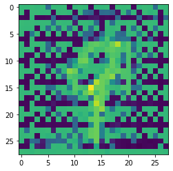

```python
print("An example of a generated image:")
TImShow(xr[0,:,:,:].cpu())
```

```
The image with no noise:
```

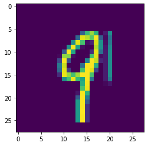

```python
print("The image with no noise:")
TImShow(batch_x[0,:,:,:].cpu())
```

```python
acc = 0
running_loss = 0
for i in range(test_x.shape[0]):
    with torch.no_grad():
        input, _ = gen(test_x[i,:,:,:].view(1,1,28,28).float().cuda())
        out = model(input)
    running_loss += criterion(out, test_y[i].view(1).cuda().long()).item()
    out = torch.argmax(out, dim = 1)

    if out == test_y[i]:
        acc+=1
print("The test accuracy after using the GAN was: " + str(acc/test_y.shape[0]))
print("The test loss after using the GAN was: " + str(running_loss/test_y.shape[0]))
```

```
The test accuracy after using the GAN was: 0.3342857142857143
The test loss after using the GAN was: 2.1183039965799875
```

```
Mean r
```

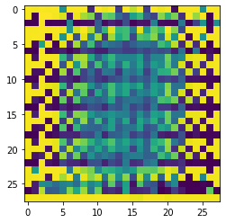

```python
print("Mean r")
TImShow(torch.mean(r.cpu(), dim = 0))
```

```python
meanR = torch.mean(sameR, dim = 0)
commonNoise = r[0,:,:,:].cpu()*(meanR>.9)
acc = 0
running_loss = 0
for i in range(test_x.shape[0]):
    with torch.no_grad():
        input = test_x[i,:,:,:] + commonNoise
        input = input.cuda().view(1,1,28,28)
        out = model(input)
    running_loss += criterion(out, test_y[i].view(1).cuda().long()).item()
    out = torch.argmax(out, dim = 1)

    if out == test_y[i]:
        acc+=1
print("The test accuracy after adding common noise was: " + str(acc/test_y.shape[0]))
print("The test loss after adding common noise was: " + str(running_loss/test_y.shape[0]))
```

```
The test accuracy after adding common noise was: 0.9909523809523809
The test loss after adding common noise was: 1.4703384344918387
```

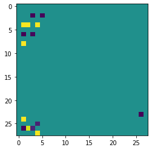

```python
TImShow(commonNoise)
```

Now we will observe the what happens if there's no sparsity loss:

```python
def getRealSamples(data, y, batch_size):
    temp = torch.randperm(batch_size)
    result = data[temp, :, :, :]
    result = result.float()
    y = y[temp].float()
    return result, y
#For reproducability (this is here because of a mistake that was made while running before, in the interest of not rerunning the whole
#notebook I've added another statement that sets the seed)
torch.backends.cudnn.deterministic = True
torch.manual_seed(0)
torch.cuda.manual_seed_all(0)
np.random.seed(0)
torch.cuda.is_available()
criterion = nn.CrossEntropyLoss()


gen = Generator().cuda()
dis = Discriminator().cuda()
batch_size = 64
#define our two optimizers
learning_rate = 5e-5
#Use two separate RMSprop optimizers, one for the generator and one for the discriminator
gOptimizer = torch.optim.RMSprop(gen.parameters(), lr=learning_rate)
dOptimizer = torch.optim.RMSprop(dis.parameters(), lr=learning_rate)
#Now we will define the training loop:
epochs = 5
batchesPerEpoch = int(np.floor(train_x.shape[0]/batch_size))
with progressbar.ProgressBar(max_value=epochs*batchesPerEpoch) as bar:
    for epoch in range(epochs):
        running_gen_loss = 0
        for i in range(batchesPerEpoch):
            epsilon = 10**-6
            #get a minibatch of the real data
            batch_x, batch_y = getRealSamples(train_x, train_y, batch_size)
            batch_x = batch_x.cuda()
            batch_y = batch_y.cuda()
            #----------
            #Train discriminator on real data
            #----------
            dOptimizer.zero_grad()
            Dx = dis(batch_x)
            dxLoss = -1*torch.mean(torch.log(Dx+epsilon))
            #find the gradients for this step
            dxLoss.backward()

            #----------
            #Train discriminator on generated data
            #----------
            Gz, _ = gen(batch_x.float())
            DGz = dis(Gz)
            dgzLoss = 1*torch.mean(torch.log(1-DGz+epsilon))
            dgzLoss.backward()
            dOptimizer.step()


            #----------
            #Get the losses for the generator
            #----------
            gOptimizer.zero_grad()

            #----------
            #Get the mask, and generated image of the generator for this step
            #----------
            batch_x, batch_y = getRealSamples(train_x, train_y, batch_size)
            batch_x = batch_x.cuda()
            batch_y = batch_y.cuda()
            xr, r = gen(batch_x.float())

            #----------
            #Find the loss and grads for sparcity and size
            #----------
            loss_size = 10*torch.mean(torch.norm(r, dim = (2,3)))
            loss_size.backward(retain_graph=True)

            #----------
            #Find the loss against the discriminator
            #----------
            loss_dis = torch.mean(torch.log(dis(xr) + epsilon))
            loss_dis.backward(retain_graph=True)

            #----------
            #Find the classification loss
            #----------
            loss_adv = -10*criterion(model(xr), batch_y.long())
            loss_adv.backward()
            gOptimizer.step()
            bar.update(i+batchesPerEpoch*epoch)
print("Done traininig")
```

```
100% (2950 of 2950) |####################| Elapsed Time: 1:12:43 Time:  1:12:43
```

```
Done traininig
```

```
An example of a generated image:
```

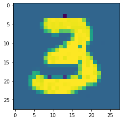

```python
print("An example of a generated image:")
TImShow(xr[0,:,:,:].cpu())
```

```
The image with no noise:
```

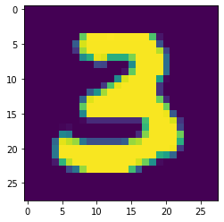

```python
print("The image with no noise:")
TImShow(batch_x[0,:,:,:].cpu())
```

```python
acc = 0
running_loss = 0
for i in range(test_x.shape[0]):
    with torch.no_grad():
        input, _ = gen(test_x[i,:,:,:].view(1,1,28,28).float().cuda())
        out = model(input)
    running_loss += criterion(out, test_y[i].view(1).cuda().long()).item()
    out = torch.argmax(out, dim = 1)

    if out == test_y[i]:
        acc+=1
print("The test accuracy after using the GAN was: " + str(acc/test_y.shape[0]))
print("The test loss after using the GAN was: " + str(running_loss/test_y.shape[0]))
```

```
The test accuracy after using the GAN was: 0.7814285714285715
The test loss after using the GAN was: 1.6774621111438388
```

```
Mean r
```

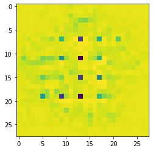

```python
print("Mean r")
TImShow(torch.mean(r.cpu(), dim = 0))
```

```python
meanR = torch.mean(sameR, dim = 0)
commonNoise = r[0,:,:,:].cpu()*(meanR>.9)
acc = 0
running_loss = 0
for i in range(test_x.shape[0]):
    with torch.no_grad():
        input = test_x[i,:,:,:] + commonNoise
        input = input.cuda().view(1,1,28,28)
        out = model(input)
    running_loss += criterion(out, test_y[i].view(1).cuda().long()).item()
    out = torch.argmax(out, dim = 1)

    if out == test_y[i]:
        acc+=1
print("The test accuracy after adding common noise was: " + str(acc/test_y.shape[0]))
print("The test loss after adding common noise was: " + str(running_loss/test_y.shape[0]))
```

```
The test accuracy after adding common noise was: 0.9914285714285714
The test loss after adding common noise was: 1.4693432777836208
```

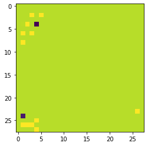

```python
TImShow(commonNoise)
```

Finally let's see what happens when we remove the discriminator:

```python
def getRealSamples(data, y, batch_size):
    temp = torch.randperm(batch_size)
    result = data[temp, :, :, :]
    result = result.float()
    y = y[temp].float()
    return result, y

criterion = nn.CrossEntropyLoss()
gen = Generator().cuda()
batch_size = 64
#define our two optimizers
learning_rate = 5e-5
#Use two separate RMSprop optimizers, one for the generator and one for the discriminator
gOptimizer = torch.optim.RMSprop(gen.parameters(), lr=learning_rate)
#Now we will define the training loop:
epochs = 5
batchesPerEpoch = int(np.floor(train_x.shape[0]/batch_size))
with progressbar.ProgressBar(max_value=epochs*batchesPerEpoch) as bar:
    for epoch in range(epochs):
        running_gen_loss = 0
        for i in range(batchesPerEpoch):
            epsilon = 10**-6
            #get a minibatch of the real data
            batch_x, batch_y = getRealSamples(train_x, train_y, batch_size)
            batch_x = batch_x.cuda()
            batch_y = batch_y.cuda()


            #----------
            #Get the losses for the generator
            #----------
            gOptimizer.zero_grad()

            #----------
            #Get the mask, and generated image of the generator for this step
            #----------
            batch_x, batch_y = getRealSamples(train_x, train_y, batch_size)
            batch_x = batch_x.cuda()
            batch_y = batch_y.cuda()
            xr, r = gen(batch_x.float())

            #----------
            #Find the loss and grads for sparcity and size
            #----------
            loss_sparse = 1000*SparseLoss(r)
            loss_sparse.backward(retain_graph=True)
            loss_size = 10*torch.mean(torch.norm(r, dim = (2,3)))
            loss_size.backward(retain_graph=True)

            #----------
            #Find the classification loss
            #----------
            loss_adv = -10*criterion(model(xr), batch_y.long())
            loss_adv.backward()
            gOptimizer.step()
            bar.update(i+batchesPerEpoch*epoch)
print("Done traininig")
```

```
100% (2950 of 2950) |####################| Elapsed Time: 0:40:36 Time:  0:40:36
```

```
Done traininig
```

```
An example of a generated image:
```

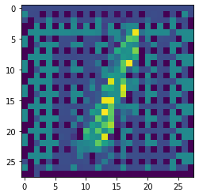

```python
print("An example of a generated image:")
TImShow(xr[0,:,:,:].cpu())
```

```
The image with no noise:
```

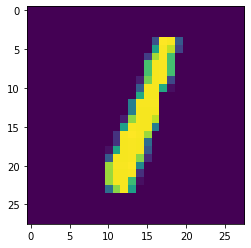

```python
print("The image with no noise:")
TImShow(batch_x[0,:,:,:].cpu())
```

```python
acc = 0
running_loss = 0
for i in range(test_x.shape[0]):
    with torch.no_grad():
        input, _ = gen(test_x[i,:,:,:].view(1,1,28,28).float().cuda())
        out = model(input)
    running_loss += criterion(out, test_y[i].view(1).cuda().long()).item()
    out = torch.argmax(out, dim = 1)

    if out == test_y[i]:
        acc+=1
print("The test accuracy after using the GAN was: " + str(acc/test_y.shape[0]))
print("The test loss after using the GAN was: " + str(running_loss/test_y.shape[0]))
```

```
The test accuracy after using the GAN was: 0.3980952380952381
The test loss after using the GAN was: 2.0568322269973303
```

```
Mean r
```

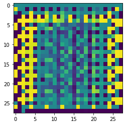

```python
print("Mean r")
TImShow(torch.mean(r.cpu(), dim = 0))
```

```python
meanR = torch.mean(sameR, dim = 0)
commonNoise = r[0,:,:,:].cpu()*(meanR>.9)
acc = 0
running_loss = 0
for i in range(test_x.shape[0]):
    with torch.no_grad():
        input = test_x[i,:,:,:] + commonNoise
        input = input.cuda().view(1,1,28,28)
        out = model(input)
    running_loss += criterion(out, test_y[i].view(1).cuda().long()).item()
    out = torch.argmax(out, dim = 1)

    if out == test_y[i]:
        acc+=1
print("The test accuracy after adding common noise was: " + str(acc/test_y.shape[0]))
print("The test loss after adding common noise was: " + str(running_loss/test_y.shape[0]))
```

```
The test accuracy after adding common noise was: 0.9909523809523809
The test loss after adding common noise was: 1.4701466364803768
```

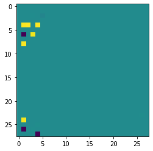

```python
TImShow(commonNoise)
```

## Some Problems with this Approach

I would like to quickly detail some problems that I had with this approach. The first is that there is nothing stopping the images generated by the generator from being invalid images. This means that the image would contain values less than negative 1 or values greater than 1. I'm hoping that the sparsity loss and size loss will make this less of a problem, and the invalid images should be easy for the discriminator to classify as fake, but this is not a rigorous way of mitigating this concern, so it is certainly still possible for the model to converge to a solution that only gives invalid images. I also would like to note that the adversarial images generated by this typically affect the digit itself substantially. This is fine in my eyes since I can still easily tell what the digit is, but it is a far cry from the almost imperceptible noise generated from other methods.

## Summary/Final Thoughts About Using GANs to Generate Adversarial Images

This worked better than I had originally hoped, and it was able to fool $\Phi$ even on a test set of images, which says to me that the generator did learn where weaknesses were in $\Phi$'s structure. This is advantageous over other methods because it does not need to optimize for each image that it would like to generate an adversarial example for, and instead can be trained once and still fool a pre trained neural net for images that it has never seen before.

# References

[1] arXiv:1312.6199 [cs.CV] (link: https://arxiv.org/abs/1312.6199)

[2] arXiv:1710.08864 [cs.LG] (link: https://arxiv.org/abs/1710.08864)

[3] arXiv:1908.07442 [cs.LG] (link: https://arxiv.org/abs/1908.07442)